# Name: Rawan Saqer AlHarbi

## Let’s also define the train function which will be used to find the model parameters that minimizes the cost function using functions above.

```python
def train(X,y, lr=0.02, iter=100):
    loss=[]
    theta=np.zeros(X.shape[1])
    for i in range(iter):
        z=f(X,theta)

        a=sigmoid(z)
        loss_=loss_fun(y,a)
        g=compute_grad(X,y, a)
        theta=theta-lr *g
        loss.append(loss_)
    print(theta)
    ##print(loss)

    rr=list(range(iter))
    plt.plot(rr, loss)
    plt.show()


    return theta
```

```
[-0.18732413 -0.16456771  0.22747216 -0.22780898]
```

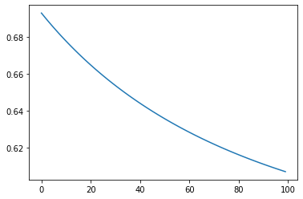

```
array([-0.18732413, -0.16456771,  0.22747216, -0.22780898])
```

```python
X=np.array([[1,0.77132064, 0.02075195, 0.63364823],
 [1, 1.74880388 ,0.49850701 ,0.22479665],
 [1, 0.19806286, 0.76053071 ,0.16911084],
 [1, 0.08833981 , 3.68535982 , -0.95339335],
 [1, -0.00394827 ,0.51219226 ,0.81262096]])


y=np.array([1,0,0,1,0])
train(X,y)
```

#### 6) - Load cancer dataset from sklearn. Split the data into 70% for traing and 30% for testing. Train the training set using train function. Then, cacluate the accuracy on testing set

```python
from sklearn.datasets import load_breast_cancer
data = load_breast_cancer()

print(data.target_names)
```

```
['malignant' 'benign']
```

```python
x = data.data
y = data.target
```

```python
from sklearn.model_selection import train_test_split
x_train, x_test, y_train, y_test = train_test_split(x,y,test_size = 0.3)
```

[output not shown]

```
[ 5.85529109e-01  8.21794300e-01  3.47486242e+00  1.37470979e+00
  5.50479339e-03 -5.37858306e-04 -8.39307581e-03 -3.68208023e-03
  1.08340192e-02  4.39592231e-03  1.56676823e-03  5.09617046e-02
 -7.76419406e-03 -1.55469319e+00  2.26255502e-04 -3.00744557e-04
 -8.54896330e-04 -5.19507392e-05  8.86101247e-04  7.31866754e-05
  6.14557625e-01  1.01963927e+00  3.57247778e+00 -1.95972008e+00
  6.62063093e-03 -5.51103145e-03 -1.49979507e-02 -3.74430253e-03
  1.46790885e-02  4.31168076e-03]
```

[figure not shown]

```python
tr = train(x_train,y_train,lr=0.002,iter = 1000)
```

```python
pred=predict(x_test,tr)

accuracy=score(y_test,pred)
```

[output not shown]

```
C:\Users\Rawan Saqer\anaconda3\lib\site-packages\ipykernel_launcher.py:2: RuntimeWarning: overflow encountered in exp
```

```python
print(accuracy)
```

```
0.9122807017543859
```

# Part 2: Naive Bayes classifier

### You have a set of customers reviews (training set) and a classification as shown in the table below.

```python
reviews=[['he likes the restaurant'],['he dislikes the restaurant'],['wonderful restaurant'],
         ['great service and fantastic food']]
labels=['positive','negitive','positive','positive' ]
```

#### 1) Write a function to return the number of all unique words in the training set

```python
def get_length_of_unique_words(corpus):

    list1 = []
    for text in corpus:
        [list1.append(word) for word in text[0].split(" ") if not word in list1]

    return len(list1)
```

```python
V=get_length_of_unique_words(reviews)
print(V)
```

```
11
```

#### 2) Write a function to return the number of all words in given class

```python
def get_length_of_all_words_for_given_class(corpus,All_labels, given_class):

    list2 = []

    for i,text in enumerate(corpus):

        [list2.append(word) for word in text[0].split(" ") if All_labels[i] == given_class]

    return len(list2)
    pass
```

```python
## Test your code to validate the results
all_words_len_for_negitive_class=get_length_of_all_words_for_given_class(reviews,labels, given_class='negitive')
print(all_words_len_for_negitive_class)


all_words_len_for_positive_class=get_length_of_all_words_for_given_class(reviews,labels, given_class='positive')
print(all_words_len_for_positive_class)
```

```
4
11
```

#### 3) Write a function to return the occurance of given word in spcific class

```python
def get_of_occurance_of_word_in_given_class(word,corpus,labels, given_class):

    list3 = []

    for i,text in enumerate(corpus):

        [list3.append(word) for Word in text[0].split(" ") if Word == word and labels[i] == given_class]

    return len(list3)
```

```python
occurance=get_of_occurance_of_word_in_given_class(word='restaurant', corpus = reviews, labels = labels, given_class = 'negitive')
print(occurance)
```

```
1
```

#### 4) Write a function to calculate the prior probablity for given class

```python
def get_prior_prob(c):

    a = 0
    b = 0

    for k in labels:
        a = a + 1
        if k == c:
            b = b + 1
    return b/a
```

```python
print(get_prior_prob('negitive'))
```

```
0.25
```

#### 4) Write a function to caclulate the likelihood for a word given a class p(word|class)

```python
## p(word|class)

def get_likelihood_for_given_word(corpus, all_labels, word, given_class):

    V=get_length_of_unique_words(reviews)
    Len_of_all_words_for_given_class=get_length_of_all_words_for_given_class(corpus,all_labels, given_class)
    occurance_ =get_of_occurance_of_word_in_given_class(word='restaurant', corpus=reviews, labels=labels, given_class='positive')

    ## apply the formula
    likelihood=(occurance_)/(Len_of_all_words_for_given_class+V)
    return likelihood
```

```python
likelihood=get_likelihood_for_given_word(reviews, labels, 'restaurant', 'negitive')
print(likelihood)
```

```
0.13333333333333333
```

# Part 3: Classification using PCA, KNN, and logesitic regression

### LFW dataset

###### The LFW dataset contains 13,233 images of faces collected from the web. This dataset consists of the 5749 identities with 1680 people with two or more images.

```python
from sklearn.datasets import fetch_lfw_people
import matplotlib.pyplot as plt
```

```python
## load lfw dataset
lfw= fetch_lfw_people(min_faces_per_person=10)
```

```python
print(lfw.DESCR)
```

[output not shown]

[output cut: 71 more lines]

```
10-folds cross validation scheme.

.. topic:: References:

 * `Labeled Faces in the Wild: A Database for Studying Face Recognition
   in Unconstrained Environments.
   <http://vis-www.cs.umass.edu/lfw/lfw.pdf>`_
   Gary B. Huang, Manu Ramesh, Tamara Berg, and Erik Learned-Miller.
   University of Massachusetts, Amherst, Technical Report 07-49, October, 2007.


Examples
~~~~~~~~

:ref:`sphx_glr_auto_examples_applications_plot_face_recognition.py`
```

```python
X=lfw.data
X.shape
## image size = 62* 47=2914
```

```
(4324, 2914)
```

### 1- Normalize the input features with mean zero and variance one

```python
from sklearn.preprocessing import StandardScaler

ssc= StandardScaler()
X = ssc.fit_transform(X)
```

```python
len(lfw.target_names)
```

```
158
```

```python
y = lfw.target
y
```

```
array([ 54,   0, 134, ...,  98, 136,  29], dtype=int64)
```

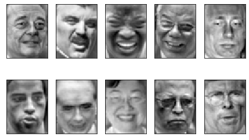

```python
def plot_faces(images, n_row=2, n_col=5):
    w=47
    h=62
    """Helper function to plot a gallery of portraits"""

    for i in range(n_row * n_col):
        plt.subplot(n_row, n_col, i + 1)
        plt.imshow(images[i].reshape((h, w)), cmap=plt.cm.gray)
        plt.xticks(())
        plt.yticks(())
    plt.tight_layout()
    plt.show()

#plot the average face and some samples from the dataset
plot_faces(X)
```

### 2- Split data to 70% for training and 30% for testing. Use train_test_split from sklearn with random_state=5

```python
from sklearn.model_selection import train_test_split
X_train, X_test, y_train, y_test = train_test_split(X, y, test_size= 0.3, random_state=5)
```

### 3- Write Python code to implement a face recognition systems using scikit-learn on lfw dataset. These systems include:

1- Logestic regression model (feed the images [raw features] into the logestic regression directly)  
2- PCA + K_NN (number of principle components=100)  
3- PCA+ logestic regression( number of principle components=100)  
4- K-NN  
5- Create a table comparsions to compare the accuracy of the Face recogniton systems above (Note: use tabulate library to print tabular data. For more details: https://pypi.org/project/tabulate/

### Logestic regression

```python
from sklearn.linear_model import LogisticRegression

classifier = LogisticRegression()
classifier.fit(X_train, y_train)
```

[output not shown]

```
LogisticRegression()
```

```python
#prediction
pred = classifier.predict(X_test)
print(pred)
```

```
[ 36 134 146 ...  88 134  13]
```

```python
#confusion matrix and accuracy score
from sklearn.metrics import confusion_matrix, accuracy_score
cm = confusion_matrix(y_test, pred)
print(cm)
```

```
[[5 0 0 ... 0 0 0]
 [0 1 0 ... 0 0 0]
 [0 0 8 ... 0 0 0]
 ...
 [0 0 0 ... 2 0 0]
 [0 1 0 ... 0 4 0]
 [0 0 1 ... 0 0 1]]
```

```python
accuracy_score1 = accuracy_score(y_test, pred)
print(accuracy_score1)
```

```
0.5084745762711864
```

### PCA and KNN

```python
from sklearn.decomposition import PCA

pca = PCA(n_components = 100)

X_train = pca.fit_transform(X_train)

X_test = pca.transform(X_test)
```

```python
from sklearn.neighbors import KNeighborsClassifier

classifier = KNeighborsClassifier()
classifier.fit(X_train, y_train)
```

```
KNeighborsClassifier()
```

```python
#predicting
y_pred = classifier.predict(X_test)
print(y_pred)
```

```
[ 12  49 155 ...  35  89  25]
```

```python
#accuracy score
from sklearn.metrics import confusion_matrix, accuracy_score
cm = confusion_matrix(y_test, y_pred)
print(cm)
```

```
[[1 0 0 ... 0 0 0]
 [0 1 0 ... 0 0 0]
 [0 0 2 ... 0 0 0]
 ...
 [0 0 1 ... 0 0 0]
 [0 1 0 ... 0 0 0]
 [0 0 0 ... 0 0 0]]
```

```python
accuracy_score2 = accuracy_score(y_test, y_pred)
print(accuracy_score2)
```

```
0.22573189522342066
```

### PCA and Logestic regression

```python
from sklearn.decomposition import PCA

pca = PCA(n_components = 100)

X_train = pca.fit_transform(X_train)
X_test = pca.transform(X_test)
```

```python
from sklearn.linear_model import LogisticRegression

classifier = LogisticRegression()

classifier.fit(X_train, y_train)
```

[output not shown]

```
LogisticRegression()
```

```python
#predictions
y_predict = classifier.predict(X_test)
print(y_predict)
```

```
[36 22 48 ... 48 89 61]
```

```python
#confusion matrix and accuracy score
from sklearn.metrics import confusion_matrix, accuracy_score
cm = confusion_matrix(y_test, y_predict)
print(cm)
```

```
[[3 0 0 ... 0 0 0]
 [0 0 0 ... 0 0 0]
 [0 0 6 ... 0 0 0]
 ...
 [0 0 0 ... 3 0 0]
 [0 1 0 ... 0 3 0]
 [0 0 1 ... 0 0 1]]
```

```python
accuracy_score3 = accuracy_score(y_test, y_predict)
print(accuracy_score3)
```

```
0.4345146379044684
```

```python
from sklearn.neighbors import KNeighborsClassifier

classifier = KNeighborsClassifier()
classifier.fit(X_train, y_train)
```

```
KNeighborsClassifier()
```

```python
#prediction
y_pred = classifier.predict(X_test)
print(y_pred)
```

```
[ 12  49 155 ...  35  89  25]
```

```python
#cm and accuracy score
from sklearn.metrics import confusion_matrix, accuracy_score
cm = confusion_matrix(y_test, y_pred)
print(cm)
```

```
[[1 0 0 ... 0 0 0]
 [0 1 0 ... 0 0 0]
 [0 0 2 ... 0 0 0]
 ...
 [0 0 1 ... 0 0 0]
 [0 1 0 ... 0 0 0]
 [0 0 0 ... 0 0 0]]
```

```python
accuracy_score4 = accuracy_score(y_test, y_pred)
print(accuracy_score4)
```

```
0.22573189522342066
```

```python
#!pip install tabulate
```

```python
from tabulate import tabulate
table = [["ML Model","Acc"],["Logestic Regression",accuracy_score1],
         ["PCA and KNN",accuracy_score2],["PCA and Logestic regression",accuracy_score3], ["K-NN",accuracy_score4]]

print(tabulate(table))
```

[output not shown]